# Project: Investigate a Dataset (Gapminder Dataset)

- Introduction
- Data Wrangling
- Exploratory Data Analysis
- Conclusions

## Introduction

> This project is an analysis of dataset that can be obtained from Gapminder World. It will explore about cellphones, cellphones per 100 people, population, Income (per person) and urban population (percent of total).It will also look at these variables to find trends, which variable are related to the cellphones.

> Gapminder is an independent Swedish foundation with no political, religious or economic affiliations. Gapminder is a fact tank, not a think tank. Gapminder fights devastating misconceptions about global development. You can find information and download dataset from the following link. https://www.gapminder.org/about-gapminder/

> These are the names and decriptions of the key variables in this report.
> - "cellphone". Mobile cellular telephone subscriptions
> - "cellphone_per_100_people". Mobile cellular telephone subscriptions per 100 people
> - "population". Number of population in each country
> - "income_per_person". Gross domestic product per person adjusted for differences in purchasing power (in international dollars, fixed 2011 prices PPP based on 2011 ICP)
> - "urban_population%". Urban population refers to people living in ueban areas as defined by national statistical offices.

## Question

> 1. Which ten countries show the largest mean of mobile cellular telephone subscriptions (cellphone) from 2009 to 2018?

>    > 1.1. If the amount of population in that country is greater than other countries, then should the cellphone will be high as the population?
> 2. Which ten countries show the largest mean of mobile cellular telephone subscriptions per 100 people (cellphone per 100 people) from 2009 to 2018?

>    > 2.1. If the amount of population in that country is greater than other countries, then should the cellphone per 100 people will be high as the population?
> 3. What is the trend of cellphone in every country between 2009 and 2018 compared to other variables?
> 4. What is the trend of cellphone (per 100 people) in every country between 2009 and 2018 compared to other variables?
> 5. What is the trend between other variables in 2009 to 2018 (urban_population%, income_per_person and population)?

```python
import numpy as np
import pandas as pd
import matplotlib.pyplot as plt
%matplotlib inline
import seaborn as sns

from functools import reduce #merge multiple dataframes together

#get better quality for visualization
%config InlineBackend.figure_format = 'retina'
```

## Data Wrangling

> Before we start to analyze this data, the data has to be wrangled and cleaned into a format which can be analyzed.

Import Data for Analyze

```python
cph = "cell_phones_total.csv"
df_cph = pd.read_csv(cph)

cph100 = "cell_phones_per_100_people.csv"
df_cph100 = pd.read_csv(cph100)

pop = "population_total.csv"
df_pop = pd.read_csv(pop)

inpp = "income_per_person_gdppercapita_ppp_inflation_adjusted.csv"
df_inpp = pd.read_csv(inpp)

urban = "urban_population_percent_of_total.csv"
df_urban = pd.read_csv(urban)
```

Let's take a look on the overall data and shape

```python
df_cph.head()
```

|  | country | 1960 | 1961 | 1962 | 1963 | 1964 | 1965 | 1966 | 1967 | 1968 | ... | 2009 | 2010 | 2011 | 2012 | 2013 | 2014 | 2015 | 2016 | 2017 | 2018 |
| --- | --- | --- | --- | --- | --- | --- | --- | --- | --- | --- | --- | --- | --- | --- | --- | --- | --- | --- | --- | --- | --- |
| 0 | Afghanistan | 0.0 | NaN | NaN | NaN | NaN | 0.0 | NaN | NaN | NaN | ... | 10500000.0 | 10200000.0 | 13800000.0 | 15300000.0 | 16800000.0 | 18400000.0 | 19700000 | 21600000.0 | 23900000.0 | 22000000.0 |
| 1 | Albania | 0.0 | NaN | NaN | NaN | NaN | 0.0 | NaN | NaN | NaN | ... | 2460000.0 | 2690000.0 | 3100000.0 | 3500000.0 | 3690000.0 | 3360000.0 | 3400000 | 3370000.0 | 3630000.0 | 2710000.0 |
| 2 | Algeria | 0.0 | NaN | NaN | NaN | NaN | 0.0 | NaN | NaN | NaN | ... | 32700000.0 | 32800000.0 | 35600000.0 | 37500000.0 | 39500000.0 | 43300000.0 | 43200000 | 47000000.0 | 45800000.0 | 47200000.0 |
| 3 | Andorra | 0.0 | NaN | NaN | NaN | NaN | 0.0 | NaN | NaN | NaN | ... | 64500.0 | 65500.0 | 65000.0 | 63900.0 | 63900.0 | 66200.0 | 71300 | 76100.0 | 80300.0 | 82600.0 |
| 4 | Angola | 0.0 | NaN | NaN | NaN | NaN | 0.0 | NaN | NaN | NaN | ... | 8110000.0 | 9400000.0 | 12100000.0 | 12800000.0 | 13300000.0 | 14100000.0 | 13900000 | 13000000.0 | 13300000.0 | 13300000.0 |

5 rows × 60 columns

Manage the data easier to use by bringing countries and years into an index with function the function of Pandas by melt

```python
#melt the dataframe to get tidy data
df_cph_melt = pd.melt(df_cph, id_vars=["country"], var_name="year", value_name= "cellphone")

#sort values by country and year
df_cph_melt.sort_values(["country", "year"], inplace = True)

#show the head of the dataframe
df_cph_melt.head()
```

|  | country | year | cellphone |
| --- | --- | --- | --- |
| 0 | Afghanistan | 1960 | 0.0 |
| 194 | Afghanistan | 1961 | NaN |
| 388 | Afghanistan | 1962 | NaN |
| 582 | Afghanistan | 1963 | NaN |
| 776 | Afghanistan | 1964 | NaN |

```python
#melt the dataframe to get tidy data
df_cph100_melt = pd.melt(df_cph100, id_vars=["country"], var_name="year", value_name= "cellphone_per_100_people")

#sort values by country and year
df_cph100_melt.sort_values(["country", "year"], inplace = True)

#show the head of the dataframe
df_cph100_melt.head()
```

|  | country | year | cellphone_per_100_people |
| --- | --- | --- | --- |
| 0 | Afghanistan | 1960 | 0.0 |
| 194 | Afghanistan | 1961 | NaN |
| 388 | Afghanistan | 1962 | NaN |
| 582 | Afghanistan | 1963 | NaN |
| 776 | Afghanistan | 1964 | NaN |

```python
#melt the dataframe to get tidy data
df_pop_melt = pd.melt(df_pop, id_vars=["country"], var_name="year", value_name= "population")

#sort values by country and year
df_pop_melt.sort_values(["country", "year"], inplace = True)

#show the head of the dataframe
df_pop_melt.head()
```

|  | country | year | population |
| --- | --- | --- | --- |
| 0 | Afghanistan | 1800 | 3280000 |
| 195 | Afghanistan | 1801 | 3280000 |
| 390 | Afghanistan | 1802 | 3280000 |
| 585 | Afghanistan | 1803 | 3280000 |
| 780 | Afghanistan | 1804 | 3280000 |

```python
#melt the dataframe to get tidy data
df_inpp_melt = pd.melt(df_inpp, id_vars=["country"], var_name="year", value_name= "income_per_person")

#sort values by country and year
df_inpp_melt.sort_values(["country", "year"], inplace = True)

#show the head of the dataframe
df_inpp_melt.head()
```

|  | country | year | income_per_person |
| --- | --- | --- | --- |
| 0 | Afghanistan | 1800 | 603 |
| 193 | Afghanistan | 1801 | 603 |
| 386 | Afghanistan | 1802 | 603 |
| 579 | Afghanistan | 1803 | 603 |
| 772 | Afghanistan | 1804 | 603 |

```python
#melt the dataframe to get tidy data
df_urban_melt = pd.melt(df_inpp, id_vars=["country"], var_name="year", value_name= "urban_population%")

#sort values by country and year
df_urban_melt.sort_values(["country", "year"], inplace = True)

#show the head of the dataframe
df_urban_melt.head()
```

|  | country | year | urban_population% |
| --- | --- | --- | --- |
| 0 | Afghanistan | 1800 | 603 |
| 193 | Afghanistan | 1801 | 603 |
| 386 | Afghanistan | 1802 | 603 |
| 579 | Afghanistan | 1803 | 603 |
| 772 | Afghanistan | 1804 | 603 |

We will create a function to generally merge the data into one dataframe to use and access data very easily., which will be done in the next cell.

```python
#From github: https://github.com/DataLind/Udacity-Data-Analyst-Nanodegree/blob/master/P1-Investigate-A-Dataset/Investigate%20Gapminder%20Data.ipynb
#From stackoverflow: https://stackoverflow.com/questions/52223045/merge-multiple-dataframes-based-on-a-common-column

def melt_df(df, valname):
    """
    INPUT:
        df: list of dataframes,
        valname: valuename as string

    OUTPUT:
        list with melted dataframes (by country and year)
    """
    #create list
    df_func = []

    #loop over list of df
    for i, x in enumerate(df):
        df_melt = pd.melt(df[i], id_vars = ["country"], var_name = 'year', value_name = valname[i])
        df_melt.sort_values(["country", "year"], inplace = True)

        #append to created list
        df_func.append(df_melt)
    return df_func
```

```python
dataframes_all = [df_cph, df_cph100, df_pop, df_inpp, df_urban]
value_names_all = ["cellphone", "cellphone_per_100_people","population", "income_per_person", "urban_population%"]

df_func_all = melt_df(dataframes_all, value_names_all)
df_all = reduce(lambda left,right: pd.merge(left,right,on =["country", "year"], how = 'left'), df_func_all)
df_all
```

|  | country | year | cellphone | cellphone_per_100_people | population | income_per_person | urban_population% |
| --- | --- | --- | --- | --- | --- | --- | --- |
| 0 | Afghanistan | 1960 | 0.0 | 0.0000 | 9000000 | 2740.0 | 0.0840 |
| 1 | Afghanistan | 1961 | NaN | NaN | 9170000 | 2700.0 | 0.0868 |
| 2 | Afghanistan | 1962 | NaN | NaN | 9350000 | 2680.0 | 0.0898 |
| 3 | Afghanistan | 1963 | NaN | NaN | 9540000 | 2670.0 | 0.0928 |
| 4 | Afghanistan | 1964 | NaN | NaN | 9740000 | 2650.0 | 0.0959 |
| 5 | Afghanistan | 1965 | 0.0 | 0.0000 | 9960000 | 2640.0 | 0.0990 |
| 6 | Afghanistan | 1966 | NaN | NaN | 10200000 | 2600.0 | 0.1020 |
| 7 | Afghanistan | 1967 | NaN | NaN | 10400000 | 2600.0 | 0.1060 |
| 8 | Afghanistan | 1968 | NaN | NaN | 10600000 | 2620.0 | 0.1090 |
| 9 | Afghanistan | 1969 | NaN | NaN | 10900000 | 2590.0 | 0.1130 |
| 10 | Afghanistan | 1970 | 0.0 | 0.0000 | 11200000 | 2570.0 | 0.1160 |
| 11 | Afghanistan | 1971 | NaN | NaN | 11500000 | 2500.0 | 0.1200 |
| 12 | Afghanistan | 1972 | NaN | NaN | 11800000 | 2030.0 | 0.1240 |
| 13 | Afghanistan | 1973 | NaN | NaN | 12100000 | 2030.0 | 0.1280 |
| 14 | Afghanistan | 1974 | NaN | NaN | 12400000 | 2080.0 | 0.1320 |
| 15 | Afghanistan | 1975 | 0.0 | 0.0000 | 12700000 | 2150.0 | 0.1360 |
| 16 | Afghanistan | 1976 | 0.0 | 0.0000 | 12900000 | 2210.0 | 0.1410 |
| 17 | Afghanistan | 1977 | 0.0 | 0.0000 | 13200000 | 2040.0 | 0.1450 |
| 18 | Afghanistan | 1978 | 0.0 | 0.0000 | 13300000 | 2130.0 | 0.1500 |
| 19 | Afghanistan | 1979 | 0.0 | 0.0000 | 13400000 | 2030.0 | 0.1540 |
| 20 | Afghanistan | 1980 | 0.0 | 0.0000 | 13400000 | 2020.0 | 0.1600 |
| 21 | Afghanistan | 1981 | 0.0 | 0.0000 | 13200000 | 2260.0 | 0.1660 |
| 22 | Afghanistan | 1982 | 0.0 | 0.0000 | 12900000 | 2500.0 | 0.1710 |
| 23 | Afghanistan | 1983 | 0.0 | 0.0000 | 12500000 | 2650.0 | 0.1770 |
| 24 | Afghanistan | 1984 | 0.0 | 0.0000 | 12200000 | 2620.0 | 0.1840 |
| 25 | Afghanistan | 1985 | 0.0 | 0.0000 | 11900000 | 2550.0 | 0.1900 |
| 26 | Afghanistan | 1986 | 0.0 | 0.0000 | 11700000 | 2620.0 | 0.1960 |
| 27 | Afghanistan | 1987 | 0.0 | 0.0000 | 11600000 | 2360.0 | 0.2030 |
| 28 | Afghanistan | 1988 | 0.0 | 0.0000 | 11600000 | 2140.0 | 0.2100 |
| 29 | Afghanistan | 1989 | 0.0 | 0.0000 | 11900000 | 1940.0 | 0.2110 |
| ... | ... | ... | ... | ... | ... | ... | ... |
| 11416 | Zimbabwe | 1989 | 0.0 | 0.0000 | 10200000 | 2830.0 | 0.2830 |
| 11417 | Zimbabwe | 1990 | 0.0 | 0.0000 | 10400000 | 2820.0 | 0.2900 |
| 11418 | Zimbabwe | 1991 | 0.0 | 0.0000 | 10700000 | 2910.0 | 0.2970 |
| 11419 | Zimbabwe | 1992 | 0.0 | 0.0000 | 10900000 | 2590.0 | 0.3050 |
| 11420 | Zimbabwe | 1993 | 0.0 | 0.0000 | 11100000 | 2570.0 | 0.3090 |
| 11421 | Zimbabwe | 1994 | 0.0 | 0.0000 | 11300000 | 2770.0 | 0.3130 |
| 11422 | Zimbabwe | 1995 | 0.0 | 0.0000 | 11400000 | 2740.0 | 0.3170 |
| 11423 | Zimbabwe | 1996 | 0.0 | 0.0000 | 11500000 | 2990.0 | 0.3210 |
| 11424 | Zimbabwe | 1997 | 5730.0 | 0.0492 | 11700000 | 3040.0 | 0.3250 |
| 11425 | Zimbabwe | 1998 | 19000.0 | 0.1620 | 11700000 | 3100.0 | 0.3290 |
| 11426 | Zimbabwe | 1999 | 174000.0 | 1.4700 | 11800000 | 3050.0 | 0.3330 |
| 11427 | Zimbabwe | 2000 | 266000.0 | 2.2400 | 11900000 | 2950.0 | 0.3380 |
| 11428 | Zimbabwe | 2001 | 314000.0 | 2.6300 | 11900000 | 2980.0 | 0.3420 |
| 11429 | Zimbabwe | 2002 | 339000.0 | 2.8300 | 12000000 | 2710.0 | 0.3460 |
| 11430 | Zimbabwe | 2003 | 364000.0 | 3.0300 | 12000000 | 2240.0 | 0.3450 |
| 11431 | Zimbabwe | 2004 | 426000.0 | 3.5400 | 12000000 | 2100.0 | 0.3430 |
| 11432 | Zimbabwe | 2005 | 647000.0 | 5.3600 | 12100000 | 1980.0 | 0.3410 |
| 11433 | Zimbabwe | 2006 | 849000.0 | 6.9900 | 12200000 | 1890.0 | 0.3390 |
| 11434 | Zimbabwe | 2007 | 1230000.0 | 10.0000 | 12300000 | 1810.0 | 0.3370 |
| 11435 | Zimbabwe | 2008 | 1650000.0 | 13.4000 | 12400000 | 1480.0 | 0.3360 |
| 11436 | Zimbabwe | 2009 | 3990000.0 | 31.9000 | 12500000 | 1630.0 | 0.3340 |
| 11437 | Zimbabwe | 2010 | 7700000.0 | 60.6000 | 12700000 | 1930.0 | 0.3320 |
| 11438 | Zimbabwe | 2011 | 9200000.0 | 71.3000 | 12900000 | 2170.0 | 0.3300 |
| 11439 | Zimbabwe | 2012 | 12600000.0 | 96.2000 | 13100000 | 2490.0 | 0.3280 |
| 11440 | Zimbabwe | 2013 | 13600000.0 | 102.0000 | 13400000 | 2490.0 | 0.3270 |
| 11441 | Zimbabwe | 2014 | 11800000.0 | 86.8000 | 13600000 | 2510.0 | 0.3250 |
| 11442 | Zimbabwe | 2015 | 12800000.0 | 92.3000 | 13800000 | 2510.0 | 0.3240 |
| 11443 | Zimbabwe | 2016 | 12900000.0 | 91.8000 | 14000000 | 2490.0 | 0.3230 |
| 11444 | Zimbabwe | 2017 | 14100000.0 | 99.0000 | 14200000 | 2570.0 | 0.3220 |
| 11445 | Zimbabwe | 2018 | 12900000.0 | 89.4000 | 14400000 | 2620.0 | 0.3220 |

11446 rows × 7 columns

> From the table above, you can see that we have combined the data into a single dataframe.

Then we will look at the data of this dataframe such as the amount of null, datatype or unique value for each year.

```python
df_all.info()
```

```
<class 'pandas.core.frame.DataFrame'>
Int64Index: 11446 entries, 0 to 11445
Data columns (total 7 columns):
country                     11446 non-null object
year                        11446 non-null object
cellphone                   8739 non-null float64
cellphone_per_100_people    8739 non-null float64
population                  11446 non-null int64
income_per_person           11387 non-null float64
urban_population%           11379 non-null float64
dtypes: float64(4), int64(1), object(2)
memory usage: 715.4+ KB
```

```python
df_year = df_all.groupby('country').mean()
df_year
```

| country | cellphone | cellphone_per_100_people | population | income_per_person | urban_population% |
| --- | --- | --- | --- | --- | --- |
| Afghanistan | 4.027979e+06 | 12.361617 | 1.803153e+07 | 1855.016949 | 0.183632 |
| Albania | 9.188511e+05 | 31.192877 | 2.723729e+06 | 5496.610169 | 0.397203 |
| Algeria | 1.065970e+07 | 28.250087 | 2.500508e+07 | 10306.779661 | 0.518983 |
| Andorra | 2.575689e+04 | 33.010426 | 5.112034e+04 | 32447.457627 | 0.870136 |
| Angola | 3.001700e+06 | 11.680434 | 1.351508e+07 | 4978.305085 | 0.365492 |
| Antigua and Barbuda | 5.057500e+04 | 57.416250 | 7.048814e+04 | 14277.796610 | 0.326136 |
| Argentina | 1.704215e+07 | 41.063395 | 3.209322e+07 | 14298.983051 | 0.850525 |
| Armenia | 8.236296e+05 | 28.230031 | 2.911695e+06 | 4510.338983 | 0.630983 |
| Australia | 8.953692e+06 | 40.991602 | 1.691525e+07 | 29676.271186 | 0.846881 |
| Austria | 4.383093e+06 | 51.988681 | 7.870000e+06 | 29961.016949 | 0.622475 |
| Azerbaijan | 2.567074e+06 | 27.668058 | 7.033898e+06 | 9068.644068 | 0.525542 |
| Bahamas | 1.125709e+05 | 31.929065 | 2.523898e+05 | 27349.152542 | 0.756492 |
| Bahrain | 5.939138e+05 | 49.284213 | 6.021695e+05 | 37816.949153 | 0.866847 |
| Bangladesh | 2.634654e+07 | 17.126573 | 1.026424e+08 | 1669.491525 | 0.189144 |
| Barbados | 1.040173e+05 | 36.892340 | 2.599322e+05 | 12329.830508 | 0.358729 |
| Belarus | 2.955506e+06 | 31.320077 | 9.446610e+06 | 8890.508475 | 0.605932 |
| Belgium | 4.461056e+06 | 40.938572 | 1.014644e+07 | 29037.288136 | 0.958542 |
| Belize | 6.067515e+04 | 18.360255 | 2.045288e+05 | 5268.135593 | 0.481492 |
| Benin | 1.946003e+06 | 19.450102 | 5.607119e+06 | 1526.610169 | 0.308075 |
| Bhutan | 1.339885e+05 | 18.749128 | 4.897288e+05 | 3116.847458 | 0.185493 |
| Bolivia | 2.445940e+06 | 23.518945 | 7.021525e+06 | 4289.830508 | 0.531407 |
| Bosnia and Herzegovina | 9.911851e+05 | 27.703294 | 3.849322e+06 | 5156.779661 | 0.368576 |
| Botswana | 7.712383e+05 | 37.718596 | 1.268475e+06 | 7440.491525 | 0.349463 |
| Brazil | 6.415756e+07 | 32.410523 | 1.440610e+08 | 10191.694915 | 0.706763 |
| Brunei | 1.548109e+05 | 39.810326 | 2.547983e+05 | 92510.169492 | 0.663153 |
| Bulgaria | 3.097447e+06 | 41.858328 | 8.221356e+06 | 10551.355932 | 0.627017 |
| Burkina Faso | 2.665536e+06 | 15.168865 | 9.844237e+06 | 998.762712 | 0.142090 |
| Burundi | 7.758637e+05 | 7.755193 | 5.695763e+06 | 790.983051 | 0.064388 |
| Cambodia | 3.805324e+06 | 25.055647 | 9.924576e+06 | 1356.796610 | 0.160198 |
| Cameroon | 3.582662e+06 | 16.183334 | 1.262864e+07 | 2725.593220 | 0.368881 |
| ... | ... | ... | ... | ... | ... |
| Sudan | 6.058566e+06 | 15.695669 | 2.135441e+07 | 2546.949153 | 0.253000 |
| Suriname | 2.027732e+05 | 37.650596 | 4.222373e+05 | 10349.322034 | 0.605847 |
| Swaziland | 2.070587e+05 | 19.156087 | 7.610508e+05 | 5266.440678 | 0.173959 |
| Sweden | 4.658357e+06 | 49.917128 | 8.615932e+06 | 30794.915254 | 0.826390 |
| Switzerland | 3.697531e+06 | 47.388385 | 6.799492e+06 | 45567.796610 | 0.735864 |
| Syria | 3.384979e+06 | 17.902936 | 1.236864e+07 | 4281.016949 | 0.481475 |
| Tajikistan | 1.639893e+06 | 20.459387 | 5.121186e+06 | 3320.000000 | 0.311390 |
| Tanzania | 7.405873e+06 | 15.115183 | 2.725424e+07 | 1741.694915 | 0.180288 |
| Thailand | 2.626220e+07 | 38.802682 | 5.266441e+07 | 7178.305085 | 0.306644 |
| Timor-Leste | 6.070706e+05 | 51.157059 | 7.859831e+05 | 3581.830508 | 0.200881 |
| Togo | 9.990745e+05 | 14.237123 | 3.988136e+06 | 1434.322034 | 0.279576 |
| Tonga | 1.920549e+04 | 18.794532 | 9.215424e+04 | 3482.033898 | 0.217932 |
| Trinidad and Tobago | 5.786376e+05 | 43.165015 | 1.156746e+06 | 16788.813559 | 0.502695 |
| Tunisia | 3.720535e+06 | 34.262502 | 7.866610e+06 | 6179.830508 | 0.554695 |
| Turkey | 2.268966e+07 | 30.899262 | 5.305763e+07 | 11636.440678 | 0.544814 |
| Turkmenistan | 1.252318e+06 | 23.044870 | 3.620678e+06 | 8712.203390 | 0.470780 |
| Tuvalu | 9.362222e+02 | 8.574667 | 8.282881e+03 | 2503.728814 | 0.379712 |
| Uganda | 4.363982e+06 | 12.042525 | 1.931915e+07 | 1155.864407 | 0.119217 |
| Ukraine | 1.684613e+07 | 37.716207 | 4.791864e+07 | 8239.491525 | 0.626136 |
| United Arab Emirates | 5.394242e+06 | 70.834297 | 2.975888e+06 | 84626.440678 | 0.804678 |
| United Kingdom | 2.970266e+07 | 47.301204 | 5.823898e+07 | 26483.050847 | 0.790034 |
| United States | 1.240492e+08 | 40.437259 | 2.543390e+08 | 36394.915254 | 0.762678 |
| Uruguay | 1.337749e+06 | 39.509857 | 3.070847e+06 | 11440.677966 | 0.882475 |
| Uzbekistan | 5.137705e+06 | 17.156864 | 1.996678e+07 | 3778.305085 | 0.427627 |
| Vanuatu | 3.948257e+04 | 15.213845 | 1.542644e+05 | 2351.525424 | 0.180492 |
| Venezuela | 8.586300e+06 | 30.364899 | 1.933271e+07 | 16038.983051 | 0.807610 |
| Vietnam | 2.961810e+07 | 32.668548 | 6.540339e+07 | 2329.491525 | 0.226119 |
| Yemen | 3.403829e+06 | 13.632283 | 1.347881e+07 | 3187.288136 | 0.214812 |
| Zambia | 2.370621e+06 | 15.637749 | 8.462203e+06 | 2784.406780 | 0.353678 |
| Zimbabwe | 2.507952e+06 | 18.574494 | 9.314746e+06 | 2378.644068 | 0.261034 |

194 rows × 5 columns

```python
df_all["year"]
```

```
0        1960
1        1961
2        1962
3        1963
4        1964
5        1965
6        1966
7        1967
8        1968
9        1969
10       1970
11       1971
12       1972
13       1973
14       1974
```

[output cut: 47 more lines]

```python
df_all.year.unique()
```

```
array(['1960', '1961', '1962', '1963', '1964', '1965', '1966', '1967',
       '1968', '1969', '1970', '1971', '1972', '1973', '1974', '1975',
       '1976', '1977', '1978', '1979', '1980', '1981', '1982', '1983',
       '1984', '1985', '1986', '1987', '1988', '1989', '1990', '1991',
       '1992', '1993', '1994', '1995', '1996', '1997', '1998', '1999',
       '2000', '2001', '2002', '2003', '2004', '2005', '2006', '2007',
       '2008', '2009', '2010', '2011', '2012', '2013', '2014', '2015',
       '2016', '2017', '2018'], dtype=object)
```

```python
df_all.isnull().sum()
```

```
country                        0
year                           0
cellphone                   2707
cellphone_per_100_people    2707
population                     0
income_per_person             59
urban_population%             67
dtype: int64
```

### Data Cleaning

We will do the data cleaning process by filtering to the value only in 2009 to 2018 to match the questions and remove the null value from the dataframe.

```python
df_filter_10year = df_all[(df_all["year"] >= '2009') & (df_all["year"] <= '2018')]
df_filter_10year
```

|  | country | year | cellphone | cellphone_per_100_people | population | income_per_person | urban_population% |
| --- | --- | --- | --- | --- | --- | --- | --- |
| 49 | Afghanistan | 2009 | 10500000.0 | 37.0 | 28400000 | 1500.0 | 0.235 |
| 50 | Afghanistan | 2010 | 10200000.0 | 35.0 | 29200000 | 1670.0 | 0.237 |
| 51 | Afghanistan | 2011 | 13800000.0 | 45.8 | 30100000 | 1630.0 | 0.239 |
| 52 | Afghanistan | 2012 | 15300000.0 | 49.2 | 31200000 | 1770.0 | 0.242 |
| 53 | Afghanistan | 2013 | 16800000.0 | 52.1 | 32300000 | 1810.0 | 0.244 |
| 54 | Afghanistan | 2014 | 18400000.0 | 55.2 | 33400000 | 1800.0 | 0.246 |
| 55 | Afghanistan | 2015 | 19700000.0 | 57.3 | 34400000 | 1770.0 | 0.248 |
| 56 | Afghanistan | 2016 | 21600000.0 | 61.1 | 35400000 | 1760.0 | 0.250 |
| 57 | Afghanistan | 2017 | 23900000.0 | 65.9 | 36300000 | 1760.0 | 0.253 |
| 58 | Afghanistan | 2018 | 22000000.0 | 59.1 | 37200000 | 1740.0 | 0.255 |
| 108 | Albania | 2009 | 2460000.0 | 82.9 | 2970000 | 9530.0 | 0.511 |
| 109 | Albania | 2010 | 2690000.0 | 91.3 | 2950000 | 9930.0 | 0.522 |
| 110 | Albania | 2011 | 3100000.0 | 106.0 | 2930000 | 10200.0 | 0.532 |
| 111 | Albania | 2012 | 3500000.0 | 120.0 | 2910000 | 10400.0 | 0.543 |
| 112 | Albania | 2013 | 3690000.0 | 127.0 | 2900000 | 10500.0 | 0.554 |
| 113 | Albania | 2014 | 3360000.0 | 116.0 | 2900000 | 10700.0 | 0.564 |
| 114 | Albania | 2015 | 3400000.0 | 118.0 | 2890000 | 11000.0 | 0.574 |
| 115 | Albania | 2016 | 3370000.0 | 117.0 | 2890000 | 11400.0 | 0.584 |
| 116 | Albania | 2017 | 3630000.0 | 126.0 | 2880000 | 11800.0 | 0.594 |
| 117 | Albania | 2018 | 2710000.0 | 94.2 | 2880000 | 12300.0 | 0.603 |
| 167 | Algeria | 2009 | 32700000.0 | 92.6 | 35300000 | 12700.0 | 0.668 |
| 168 | Algeria | 2010 | 32800000.0 | 91.1 | 36000000 | 12900.0 | 0.675 |
| 169 | Algeria | 2011 | 35600000.0 | 97.1 | 36700000 | 13000.0 | 0.682 |
| 170 | Algeria | 2012 | 37500000.0 | 100.0 | 37400000 | 13200.0 | 0.689 |
| 171 | Algeria | 2013 | 39500000.0 | 104.0 | 38100000 | 13300.0 | 0.696 |
| 172 | Algeria | 2014 | 43300000.0 | 111.0 | 38900000 | 13500.0 | 0.702 |
| 173 | Algeria | 2015 | 43200000.0 | 109.0 | 39700000 | 13800.0 | 0.708 |
| 174 | Algeria | 2016 | 47000000.0 | 116.0 | 40600000 | 13900.0 | 0.715 |
| 175 | Algeria | 2017 | 45800000.0 | 111.0 | 41400000 | 13900.0 | 0.721 |
| 176 | Algeria | 2018 | 47200000.0 | 112.0 | 42200000 | 13900.0 | 0.726 |
| ... | ... | ... | ... | ... | ... | ... | ... |
| 11318 | Yemen | 2009 | 8310000.0 | 36.9 | 22500000 | 4360.0 | 0.312 |
| 11319 | Yemen | 2010 | 11100000.0 | 47.9 | 23200000 | 4570.0 | 0.318 |
| 11320 | Yemen | 2011 | 11700000.0 | 49.0 | 23800000 | 3880.0 | 0.324 |
| 11321 | Yemen | 2012 | 13900000.0 | 56.8 | 24500000 | 3860.0 | 0.330 |
| 11322 | Yemen | 2013 | 16800000.0 | 67.0 | 25100000 | 3940.0 | 0.336 |
| 11323 | Yemen | 2014 | 17100000.0 | 66.2 | 25800000 | 3830.0 | 0.342 |
| 11324 | Yemen | 2015 | 15000000.0 | 56.7 | 26500000 | 3110.0 | 0.348 |
| 11325 | Yemen | 2016 | 16400000.0 | 60.5 | 27200000 | 2620.0 | 0.354 |
| 11326 | Yemen | 2017 | 15400000.0 | 55.2 | 27800000 | 2400.0 | 0.360 |
| 11327 | Yemen | 2018 | 15300000.0 | 53.7 | 28500000 | 2360.0 | 0.366 |
| 11377 | Zambia | 2009 | 4410000.0 | 33.3 | 13200000 | 3120.0 | 0.389 |
| 11378 | Zambia | 2010 | 5450000.0 | 40.0 | 13600000 | 3340.0 | 0.394 |
| 11379 | Zambia | 2011 | 8160000.0 | 58.2 | 14000000 | 3420.0 | 0.399 |
| 11380 | Zambia | 2012 | 10500000.0 | 72.8 | 14500000 | 3570.0 | 0.404 |
| 11381 | Zambia | 2013 | 10400000.0 | 69.6 | 14900000 | 3630.0 | 0.409 |
| 11382 | Zambia | 2014 | 10100000.0 | 65.7 | 15400000 | 3690.0 | 0.414 |
| 11383 | Zambia | 2015 | 11600000.0 | 72.8 | 15900000 | 3680.0 | 0.419 |
| 11384 | Zambia | 2016 | 12000000.0 | 73.4 | 16400000 | 3700.0 | 0.424 |
| 11385 | Zambia | 2017 | 13400000.0 | 79.7 | 16900000 | 3720.0 | 0.430 |
| 11386 | Zambia | 2018 | 15500000.0 | 89.2 | 17400000 | 3740.0 | 0.435 |
| 11436 | Zimbabwe | 2009 | 3990000.0 | 31.9 | 12500000 | 1630.0 | 0.334 |
| 11437 | Zimbabwe | 2010 | 7700000.0 | 60.6 | 12700000 | 1930.0 | 0.332 |
| 11438 | Zimbabwe | 2011 | 9200000.0 | 71.3 | 12900000 | 2170.0 | 0.330 |
| 11439 | Zimbabwe | 2012 | 12600000.0 | 96.2 | 13100000 | 2490.0 | 0.328 |
| 11440 | Zimbabwe | 2013 | 13600000.0 | 102.0 | 13400000 | 2490.0 | 0.327 |
| 11441 | Zimbabwe | 2014 | 11800000.0 | 86.8 | 13600000 | 2510.0 | 0.325 |
| 11442 | Zimbabwe | 2015 | 12800000.0 | 92.3 | 13800000 | 2510.0 | 0.324 |
| 11443 | Zimbabwe | 2016 | 12900000.0 | 91.8 | 14000000 | 2490.0 | 0.323 |
| 11444 | Zimbabwe | 2017 | 14100000.0 | 99.0 | 14200000 | 2570.0 | 0.322 |
| 11445 | Zimbabwe | 2018 | 12900000.0 | 89.4 | 14400000 | 2620.0 | 0.322 |

1940 rows × 7 columns

> The table above filters the year we want to use.

```python
df_filter_10year_dropna = df_filter_10year.dropna(inplace=False)
df_filter_10year_dropna
```

|  | country | year | cellphone | cellphone_per_100_people | population | income_per_person | urban_population% |
| --- | --- | --- | --- | --- | --- | --- | --- |
| 49 | Afghanistan | 2009 | 10500000.0 | 37.0 | 28400000 | 1500.0 | 0.235 |
| 50 | Afghanistan | 2010 | 10200000.0 | 35.0 | 29200000 | 1670.0 | 0.237 |
| 51 | Afghanistan | 2011 | 13800000.0 | 45.8 | 30100000 | 1630.0 | 0.239 |
| 52 | Afghanistan | 2012 | 15300000.0 | 49.2 | 31200000 | 1770.0 | 0.242 |
| 53 | Afghanistan | 2013 | 16800000.0 | 52.1 | 32300000 | 1810.0 | 0.244 |
| 54 | Afghanistan | 2014 | 18400000.0 | 55.2 | 33400000 | 1800.0 | 0.246 |
| 55 | Afghanistan | 2015 | 19700000.0 | 57.3 | 34400000 | 1770.0 | 0.248 |
| 56 | Afghanistan | 2016 | 21600000.0 | 61.1 | 35400000 | 1760.0 | 0.250 |
| 57 | Afghanistan | 2017 | 23900000.0 | 65.9 | 36300000 | 1760.0 | 0.253 |
| 58 | Afghanistan | 2018 | 22000000.0 | 59.1 | 37200000 | 1740.0 | 0.255 |
| 108 | Albania | 2009 | 2460000.0 | 82.9 | 2970000 | 9530.0 | 0.511 |
| 109 | Albania | 2010 | 2690000.0 | 91.3 | 2950000 | 9930.0 | 0.522 |
| 110 | Albania | 2011 | 3100000.0 | 106.0 | 2930000 | 10200.0 | 0.532 |
| 111 | Albania | 2012 | 3500000.0 | 120.0 | 2910000 | 10400.0 | 0.543 |
| 112 | Albania | 2013 | 3690000.0 | 127.0 | 2900000 | 10500.0 | 0.554 |
| 113 | Albania | 2014 | 3360000.0 | 116.0 | 2900000 | 10700.0 | 0.564 |
| 114 | Albania | 2015 | 3400000.0 | 118.0 | 2890000 | 11000.0 | 0.574 |
| 115 | Albania | 2016 | 3370000.0 | 117.0 | 2890000 | 11400.0 | 0.584 |
| 116 | Albania | 2017 | 3630000.0 | 126.0 | 2880000 | 11800.0 | 0.594 |
| 117 | Albania | 2018 | 2710000.0 | 94.2 | 2880000 | 12300.0 | 0.603 |
| 167 | Algeria | 2009 | 32700000.0 | 92.6 | 35300000 | 12700.0 | 0.668 |
| 168 | Algeria | 2010 | 32800000.0 | 91.1 | 36000000 | 12900.0 | 0.675 |
| 169 | Algeria | 2011 | 35600000.0 | 97.1 | 36700000 | 13000.0 | 0.682 |
| 170 | Algeria | 2012 | 37500000.0 | 100.0 | 37400000 | 13200.0 | 0.689 |
| 171 | Algeria | 2013 | 39500000.0 | 104.0 | 38100000 | 13300.0 | 0.696 |
| 172 | Algeria | 2014 | 43300000.0 | 111.0 | 38900000 | 13500.0 | 0.702 |
| 173 | Algeria | 2015 | 43200000.0 | 109.0 | 39700000 | 13800.0 | 0.708 |
| 174 | Algeria | 2016 | 47000000.0 | 116.0 | 40600000 | 13900.0 | 0.715 |
| 175 | Algeria | 2017 | 45800000.0 | 111.0 | 41400000 | 13900.0 | 0.721 |
| 176 | Algeria | 2018 | 47200000.0 | 112.0 | 42200000 | 13900.0 | 0.726 |
| ... | ... | ... | ... | ... | ... | ... | ... |
| 11318 | Yemen | 2009 | 8310000.0 | 36.9 | 22500000 | 4360.0 | 0.312 |
| 11319 | Yemen | 2010 | 11100000.0 | 47.9 | 23200000 | 4570.0 | 0.318 |
| 11320 | Yemen | 2011 | 11700000.0 | 49.0 | 23800000 | 3880.0 | 0.324 |
| 11321 | Yemen | 2012 | 13900000.0 | 56.8 | 24500000 | 3860.0 | 0.330 |
| 11322 | Yemen | 2013 | 16800000.0 | 67.0 | 25100000 | 3940.0 | 0.336 |
| 11323 | Yemen | 2014 | 17100000.0 | 66.2 | 25800000 | 3830.0 | 0.342 |
| 11324 | Yemen | 2015 | 15000000.0 | 56.7 | 26500000 | 3110.0 | 0.348 |
| 11325 | Yemen | 2016 | 16400000.0 | 60.5 | 27200000 | 2620.0 | 0.354 |
| 11326 | Yemen | 2017 | 15400000.0 | 55.2 | 27800000 | 2400.0 | 0.360 |
| 11327 | Yemen | 2018 | 15300000.0 | 53.7 | 28500000 | 2360.0 | 0.366 |
| 11377 | Zambia | 2009 | 4410000.0 | 33.3 | 13200000 | 3120.0 | 0.389 |
| 11378 | Zambia | 2010 | 5450000.0 | 40.0 | 13600000 | 3340.0 | 0.394 |
| 11379 | Zambia | 2011 | 8160000.0 | 58.2 | 14000000 | 3420.0 | 0.399 |
| 11380 | Zambia | 2012 | 10500000.0 | 72.8 | 14500000 | 3570.0 | 0.404 |
| 11381 | Zambia | 2013 | 10400000.0 | 69.6 | 14900000 | 3630.0 | 0.409 |
| 11382 | Zambia | 2014 | 10100000.0 | 65.7 | 15400000 | 3690.0 | 0.414 |
| 11383 | Zambia | 2015 | 11600000.0 | 72.8 | 15900000 | 3680.0 | 0.419 |
| 11384 | Zambia | 2016 | 12000000.0 | 73.4 | 16400000 | 3700.0 | 0.424 |
| 11385 | Zambia | 2017 | 13400000.0 | 79.7 | 16900000 | 3720.0 | 0.430 |
| 11386 | Zambia | 2018 | 15500000.0 | 89.2 | 17400000 | 3740.0 | 0.435 |
| 11436 | Zimbabwe | 2009 | 3990000.0 | 31.9 | 12500000 | 1630.0 | 0.334 |
| 11437 | Zimbabwe | 2010 | 7700000.0 | 60.6 | 12700000 | 1930.0 | 0.332 |
| 11438 | Zimbabwe | 2011 | 9200000.0 | 71.3 | 12900000 | 2170.0 | 0.330 |
| 11439 | Zimbabwe | 2012 | 12600000.0 | 96.2 | 13100000 | 2490.0 | 0.328 |
| 11440 | Zimbabwe | 2013 | 13600000.0 | 102.0 | 13400000 | 2490.0 | 0.327 |
| 11441 | Zimbabwe | 2014 | 11800000.0 | 86.8 | 13600000 | 2510.0 | 0.325 |
| 11442 | Zimbabwe | 2015 | 12800000.0 | 92.3 | 13800000 | 2510.0 | 0.324 |
| 11443 | Zimbabwe | 2016 | 12900000.0 | 91.8 | 14000000 | 2490.0 | 0.323 |
| 11444 | Zimbabwe | 2017 | 14100000.0 | 99.0 | 14200000 | 2570.0 | 0.322 |
| 11445 | Zimbabwe | 2018 | 12900000.0 | 89.4 | 14400000 | 2620.0 | 0.322 |

1884 rows × 7 columns

> The table above has removed the null values.

```python
df_filter_10year_dropna.info()
```

```
<class 'pandas.core.frame.DataFrame'>
Int64Index: 1884 entries, 49 to 11445
Data columns (total 7 columns):
country                     1884 non-null object
year                        1884 non-null object
cellphone                   1884 non-null float64
cellphone_per_100_people    1884 non-null float64
population                  1884 non-null int64
income_per_person           1884 non-null float64
urban_population%           1884 non-null float64
dtypes: float64(4), int64(1), object(2)
memory usage: 117.8+ KB
```

```python
df_filter_10year_dropna.describe()
```

|  | cellphone | cellphone_per_100_people | population | income_per_person | urban_population% |
| --- | --- | --- | --- | --- | --- |
| count | 1.884000e+03 | 1884.000000 | 1.884000e+03 | 1884.000000 | 1884.000000 |
| mean | 3.478258e+07 | 98.163430 | 3.814242e+07 | 17633.004246 | 0.576786 |
| std | 1.203960e+08 | 39.338449 | 1.421553e+08 | 19193.977344 | 0.229220 |
| min | 1.000000e+03 | 0.284000 | 1.000000e+04 | 614.000000 | 0.104000 |
| 25% | 1.937500e+06 | 71.075000 | 2.060000e+06 | 3647.500000 | 0.392750 |
| 50% | 7.175000e+06 | 103.000000 | 8.555000e+06 | 10900.000000 | 0.576500 |
| 75% | 2.162500e+07 | 125.000000 | 2.690000e+07 | 25025.000000 | 0.767000 |
| max | 1.650000e+09 | 213.000000 | 1.430000e+09 | 124000.000000 | 1.000000 |

```python
df_filter_10year_dropna.isnull().sum()
```

```
country                     0
year                        0
cellphone                   0
cellphone_per_100_people    0
population                  0
income_per_person           0
urban_population%           0
dtype: int64
```

After verifying that there are identical non-null numbers, we are ready to explore!

## Exploratory Data Analysis

### Question 1 - Which ten countries show the largest mean of mobile cellular telephone subscriptions (cellphone) from 2009 to 2018?

We will bring the available data from data cleaning process into group by country, sort data by value of cellphone ,select the desired value to analyze only the top 10 values and then ploting the bar chart (data visualization).

```python
df_cph_desc = df_filter_10year_dropna.groupby('country', as_index= False).mean().sort_values('cellphone', ascending=False)
df_cph_desc.head()
```

|  | country | cellphone | cellphone_per_100_people | population | income_per_person | urban_population% |
| --- | --- | --- | --- | --- | --- | --- |
| 35 | China | 1.199200e+09 | 85.71 | 1.395000e+09 | 12363.0 | 0.5361 |
| 75 | India | 9.346000e+08 | 72.16 | 1.287000e+09 | 5382.0 | 0.3224 |
| 184 | United States | 3.428000e+08 | 107.85 | 3.172000e+08 | 51890.0 | 0.8142 |
| 76 | Indonesia | 3.025000e+08 | 118.40 | 2.534000e+08 | 9821.0 | 0.5228 |
| 23 | Brazil | 2.327000e+08 | 115.32 | 2.018000e+08 | 14710.0 | 0.8532 |

Cellphone Top 10 in 2009 to 2018

```python
df_cph_top10 = df_cph_desc[:10]
df_cph_top10
```

|  | country | cellphone | cellphone_per_100_people | population | income_per_person | urban_population% |
| --- | --- | --- | --- | --- | --- | --- |
| 35 | China | 1.199200e+09 | 85.71 | 1.395000e+09 | 12363.0 | 0.5361 |
| 75 | India | 9.346000e+08 | 72.16 | 1.287000e+09 | 5382.0 | 0.3224 |
| 184 | United States | 3.428000e+08 | 107.85 | 3.172000e+08 | 51890.0 | 0.8142 |
| 76 | Indonesia | 3.025000e+08 | 118.40 | 2.534000e+08 | 9821.0 | 0.5228 |
| 23 | Brazil | 2.327000e+08 | 115.32 | 2.018000e+08 | 14710.0 | 0.8532 |
| 140 | Russia | 2.231000e+08 | 154.50 | 1.445000e+08 | 24490.0 | 0.7396 |
| 83 | Japan | 1.500000e+08 | 117.04 | 1.281000e+08 | 37080.0 | 0.9115 |
| 123 | Nigeria | 1.259000e+08 | 71.26 | 1.745000e+08 | 5343.0 | 0.4651 |
| 128 | Pakistan | 1.247500e+08 | 64.11 | 1.934000e+08 | 4378.0 | 0.3571 |
| 189 | Vietnam | 1.231200e+08 | 134.70 | 9.127000e+07 | 5289.0 | 0.3280 |

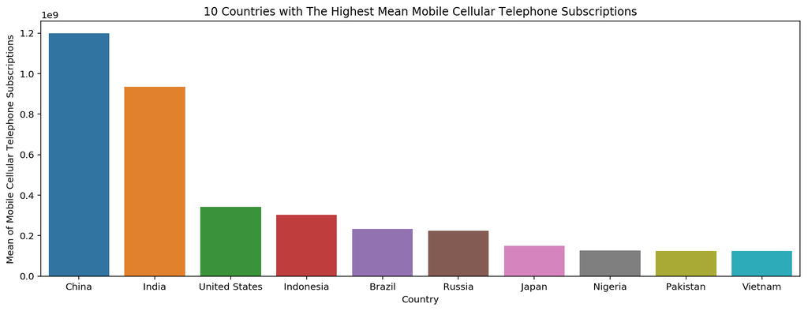

```python
plt.figure(figsize=(14.5,5))
plt.title('10 Countries with The Highest Mean Mobile Cellular Telephone Subscriptions')
ax_cph = sns.barplot(x='country', y='cellphone', data=df_cph_top10)
ax_cph.set(xlabel='Country', ylabel='Mean of Mobile Cellular Telephone Subscriptions');
plt.show()
```

#### Question 1.1.

If the amount of population in that country is greater than other countries, then should the cellphone will be high as the population?

We will plot the bar graph comparing with two variables.

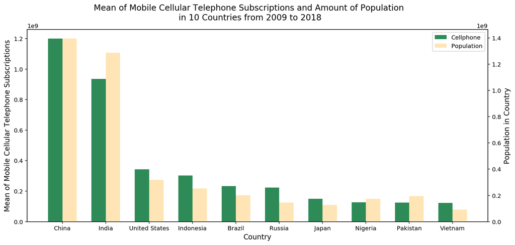

```python
#From github: https://github.com/jmlcode/p1-investigate-datasets/blob/master/p1_investigate_datasets.ipynb
# Plot mean off cellphone and population for top 10 country from the most cellphone subscriptions country in 2009 to 2018
fig, ax1 = plt.subplots(nrows = 1, ncols = 1, figsize = (14,6))

x_loc = np.arange(len(df_cph_top10)) #array([0, 1, 2, 3, 4, 5, 6, 7, 8, 9])
width = 0.33
locations = x_loc + width/2 #set bar chart to center of the country label
labels = list(df_cph_top10['country'])

# Bar plot
mean_cellphone = ax1.bar(x = x_loc, width = width
                      , height = df_cph_top10['cellphone']
                      , color = 'seagreen'
                      , label = 'Cellphone')
ax2 = ax1.twinx() # Create 2nd bar plot for the right y-axis
amount_population = ax2.bar(x = x_loc + width, width = width
                   , height = df_cph_top10['population']
                   , color = 'moccasin'
                   , label = 'Population')

fig.suptitle('Mean of Mobile Cellular Telephone Subscriptions and Amount of Population \nin 10 Countries from 2009 to 2018', fontsize = 14)
plt.xticks(locations, labels)
ax1.set_xlabel('Country', fontsize = 12)
ax1.set_ylabel('Mean of Mobile Cellular Telephone Subscriptions', fontsize = 12)
ax2.set_ylabel('Population in Country', fontsize = 12)
plt.legend(handles = [mean_cellphone, amount_population]
           , labels = ['Cellphone', 'Population']
           , loc = 'upper right'); #Color Label on Upper Right
```

It looks like this bar graph shows that the cellphone varies with the population. We will plot the scatter to find the relationship again.

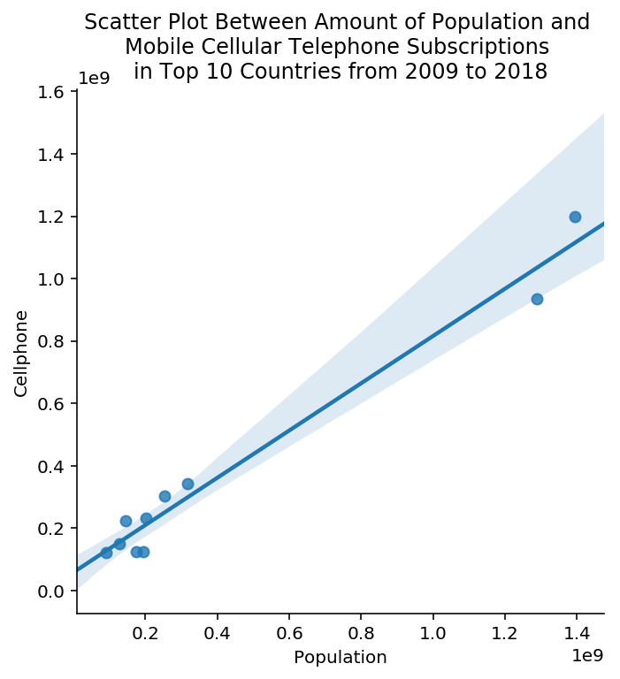

```python
sns.lmplot(x='population', y='cellphone', data=df_cph_top10[['cellphone', 'population']]);
plt.xlabel("Population")
plt.ylabel("Cellphone")
plt.title("Scatter Plot Between Amount of Population and \nMobile Cellular Telephone Subscriptions \nin Top 10 Countries from 2009 to 2018");
```

It seems that the population in the country is high, which will make a high cellphone as well.

#### Question 2.1.

If the amount of population in that country is greater than other countries, then should the cellphone (per 100 people) will be high as the population?

We will plot the bar graph comparing with two variables.

```python
df_cph100_desc = df_filter_10year_dropna.groupby('country', as_index= False).mean().sort_values('cellphone_per_100_people', ascending=False)
df_cph100_top10 = df_cph100_desc[:10]
df_cph100_top10
```

|  | country | cellphone | cellphone_per_100_people | population | income_per_person | urban_population% |
| --- | --- | --- | --- | --- | --- | --- |
| 112 | Montenegro | 1.083500e+06 | 173.300000 | 6.261000e+05 | 15050.000000 | 0.653000 |
| 182 | United Arab Emirates | 1.577000e+07 | 172.800000 | 9.071000e+06 | 61810.000000 | 0.851800 |
| 5 | Antigua and Barbuda | 1.533333e+05 | 167.888889 | 9.133333e+04 | 21255.555556 | 0.254778 |
| 88 | Kuwait | 6.020000e+06 | 166.380000 | 3.555000e+06 | 73410.000000 | 1.000000 |
| 145 | Saudi Arabia | 4.915000e+07 | 163.500000 | 3.034000e+07 | 48550.000000 | 0.828500 |
| 131 | Panama | 6.066000e+06 | 157.500000 | 3.874000e+06 | 19280.000000 | 0.662400 |
| 12 | Bahrain | 2.128000e+06 | 156.700000 | 1.353000e+06 | 42190.000000 | 0.889000 |
| 140 | Russia | 2.231000e+08 | 154.500000 | 1.445000e+08 | 24490.000000 | 0.739600 |
| 96 | Lithuania | 4.596000e+06 | 154.000000 | 2.987000e+06 | 25540.000000 | 0.671100 |
| 101 | Maldives | 6.644000e+05 | 152.900000 | 4.290000e+05 | 12640.000000 | 0.379000 |

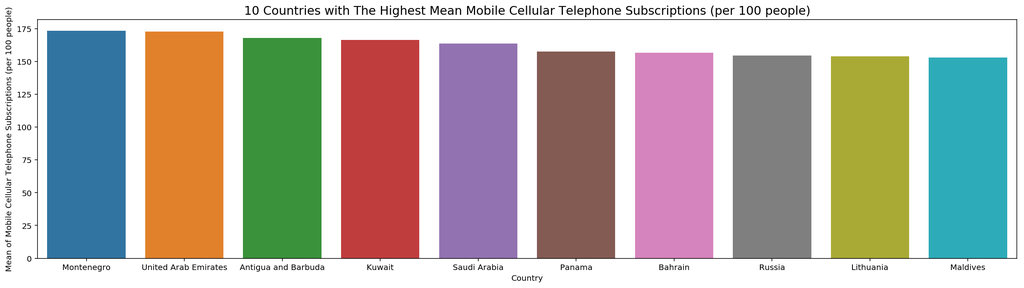

```python
plt.figure(figsize=(22,5.5))
plt.title('10 Countries with The Highest Mean Mobile Cellular Telephone Subscriptions (per 100 people)', fontsize = 15)
ax_cph100 = sns.barplot(x='country', y='cellphone_per_100_people', data=df_cph100_top10)
ax_cph100.set(xlabel='Country', ylabel='Mean of Mobile Cellular Telephone Subscriptions (per 100 people)');
plt.show()
```

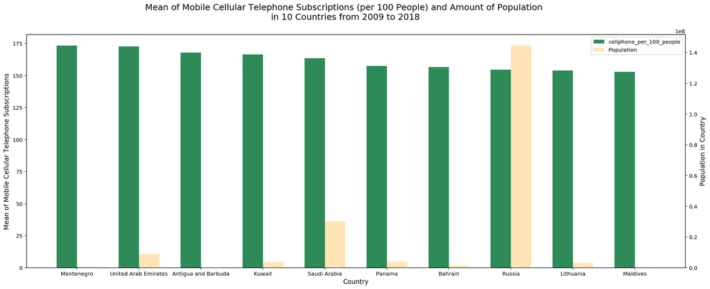

```python
#From github: https://github.com/jmlcode/p1-investigate-datasets/blob/master/p1_investigate_datasets.ipynb
# Plot mean off cellphone and population for top 10 country from the most cellphone subscriptions country in 2009 to 2018
fig, ax1 = plt.subplots(nrows = 1, ncols = 1, figsize = (22,8))

x_loc = np.arange(len(df_cph100_top10)) #array([0, 1, 2, 3, 4, 5, 6, 7, 8, 9])
width = 0.33
locations = x_loc + width/2 #set bar chart to center of the country label
labels = list(df_cph100_top10['country'])

# Bar plot
mean_cellphone100 = ax1.bar(x = x_loc, width = width
                      , height = df_cph100_top10['cellphone_per_100_people']
                      , color = 'seagreen'
                      , label = 'Cellphone per 100 people')
ax2 = ax1.twinx() # Create 2nd bar plot for the right y-axis
amount_population = ax2.bar(x = x_loc + width, width = width
                   , height = df_cph100_top10['population']
                   , color = 'moccasin'
                   , label = 'Population')

fig.suptitle('Mean of Mobile Cellular Telephone Subscriptions (per 100 People) and Amount of Population \nin 10 Countries from 2009 to 2018', fontsize = 16)
plt.xticks(locations, labels)
ax1.set_xlabel('Country', fontsize = 12)
ax1.set_ylabel('Mean of Mobile Cellular Telephone Subscriptions', fontsize = 12)
ax2.set_ylabel('Population in Country', fontsize = 12)
plt.legend(handles = [mean_cellphone100, amount_population]
           , labels = ['cellphone_per_100_people', 'Population']
           , loc = 'upper right'); #Color Label on Upper Right
```

> It seems that the population in the country is high, which will not make a high cellphone per 100 as well.

### Question 3 - What is the trend of cellphone in every country between 2009 and 2018 compared to other variables?

To find trends in this question, we will plot the histogram to see the distribution of data, plot the scatter to see the relationship of various variables and find the correlation value to analyze trends.

```python
df_filter_10year_dropna.median()
```

```
cellphone                   7.175000e+06
cellphone_per_100_people    1.030000e+02
population                  8.555000e+06
income_per_person           1.090000e+04
urban_population%           5.765000e-01
dtype: float64
```

```python
df_filter_10year_dropna.columns
```

```
Index(['country', 'year', 'cellphone', 'cellphone_per_100_people',
       'population', 'income_per_person', 'urban_population%'],
      dtype='object')
```

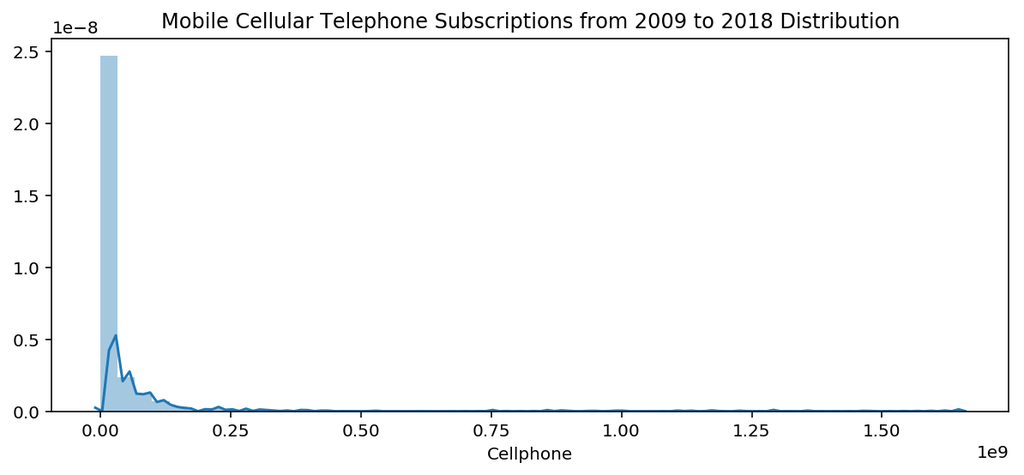

```python
plt.figure(figsize=(10,4))
sns.distplot(df_filter_10year_dropna["cellphone"]);
plt.xlabel("Cellphone")
plt.title("Mobile Cellular Telephone Subscriptions from 2009 to 2018 Distribution");
```

> The cellphone distribution in 2009 to 2018 is right-skewed

```python
df_filter_10year_dropna[['cellphone', 'population','income_per_person','urban_population%']].corr().iloc[:1]
```

|  | cellphone | population | income_per_person | urban_population% |
| --- | --- | --- | --- | --- |
| cellphone | 1.0 | 0.968848 | -0.012284 | -0.003882 |

> The correlation value of these variables

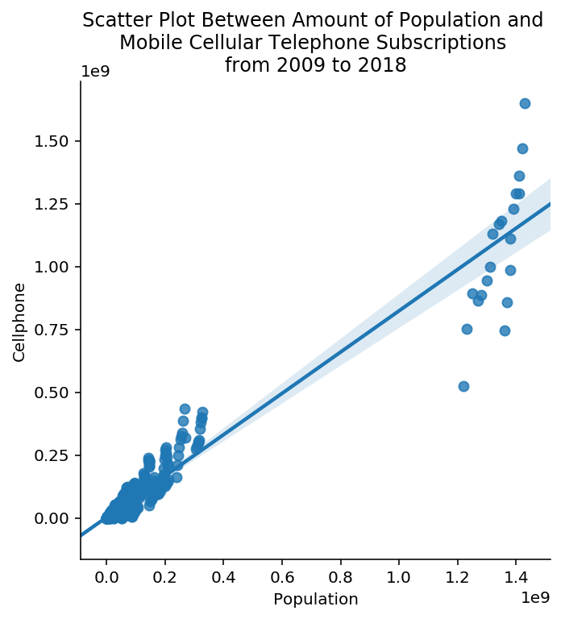

```python
sns.lmplot(x='population', y='cellphone', data=df_filter_10year_dropna[['cellphone', 'population']]);
plt.xlabel("Population")
plt.ylabel("Cellphone")
plt.title("Scatter Plot Between Amount of Population and \nMobile Cellular Telephone Subscriptions \nfrom 2009 to 2018");
```

> Therefore, the population have a positive relationship with the cellphone.

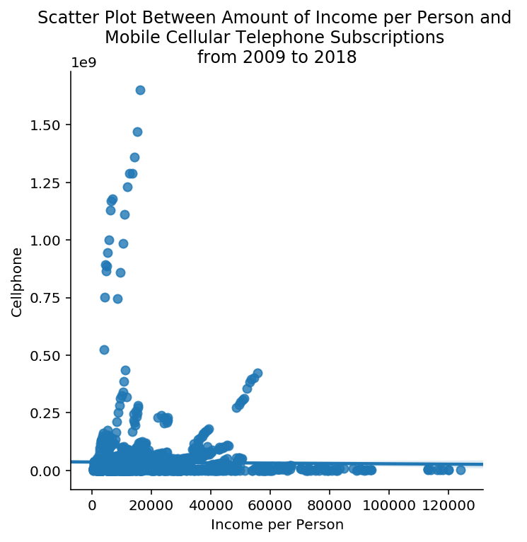

```python
sns.lmplot(x='income_per_person', y='cellphone', data=df_filter_10year_dropna[['cellphone', 'income_per_person']]);
plt.xlabel("Income per Person")
plt.ylabel("Cellphone")
plt.title("Scatter Plot Between Amount of Income per Person and \nMobile Cellular Telephone Subscriptions \nfrom 2009 to 2018");
```

> - Scatter plots: The plot and the regression line show that the relationship between income per person and cellphone is extremely low negative
> - Correlation: The corr() function gives a extremely low negative value between these two variables.

> The analysis shows that this relationship will have a lot of cellphone at the income per person less than 20000.

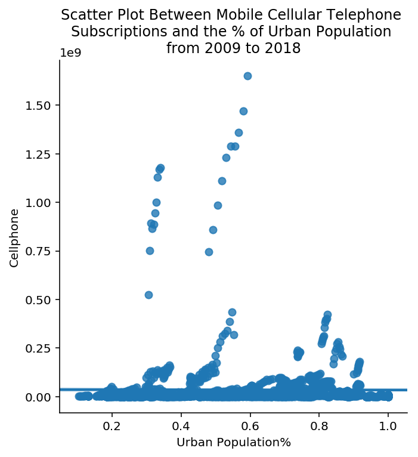

```python
sns.lmplot(x='urban_population%', y='cellphone', data=df_filter_10year_dropna[['cellphone', 'urban_population%']]);
plt.xlabel("Urban Population%")
plt.ylabel("Cellphone")
plt.title("Scatter Plot Between Mobile Cellular Telephone \nSubscriptions and the % of Urban Population \nfrom 2009 to 2018");
```

> - Scatter plots: The plot and the regression line show that the relationship between urban_population% and cellphone is extremely low negative
> - Correlation: The corr() function gives a extremely low negative value between these two variables.

> The analysis shows that this relationship will have a lot of cellphone at the urban_population% around 0.3 and range around from 0.45 to 0.55

We can see an overview of scatter plot and distribution of all variables as shown in the table below.

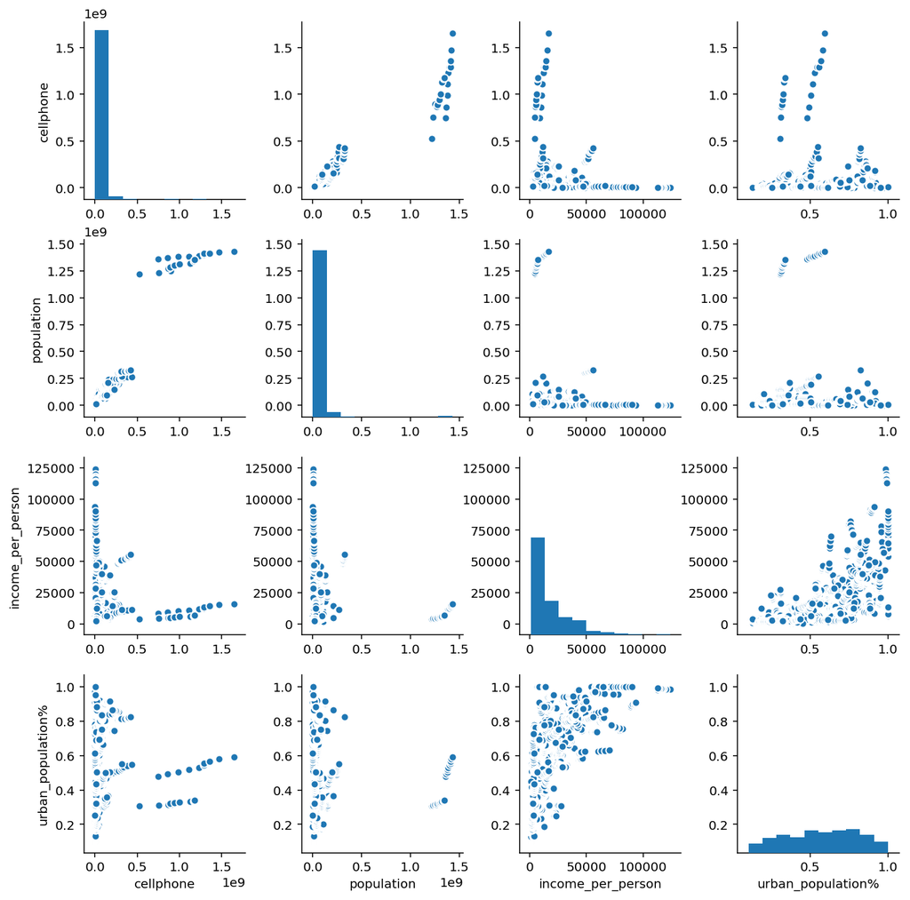

```python
sns.pairplot(data=df_filter_10year_dropna[['cellphone', 'population','income_per_person','urban_population%']]);
```

### Question 4 - What is the trend of cellphone (per 100 people) in every country between 2009 and 2018 compared to other variables?

To find trends in this question, we will plot the histogram to see the distribution of data, plot the scatter to see the relationship of various variables and find the correlation value to analyze trends.

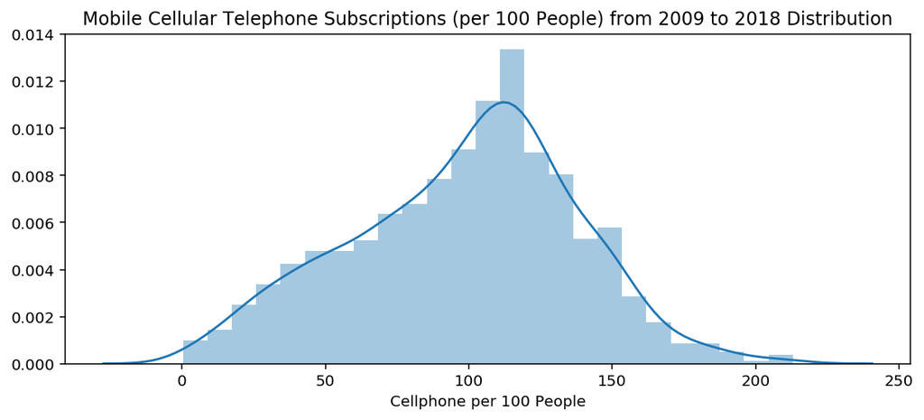

```python
plt.figure(figsize=(10,4))
sns.distplot(df_filter_10year_dropna['cellphone_per_100_people']);
plt.xlabel("Cellphone per 100 People")
plt.title("Mobile Cellular Telephone Subscriptions (per 100 People) from 2009 to 2018 Distribution");
```

```python
df_filter_10year[['cellphone_per_100_people', 'population','income_per_person','urban_population%']].corr().iloc[:1]
```

|  | cellphone_per_100_people | population | income_per_person | urban_population% |
| --- | --- | --- | --- | --- |
| cellphone_per_100_people | 1.0 | -0.045913 | 0.505701 | 0.475806 |

> The correlation value of these variables

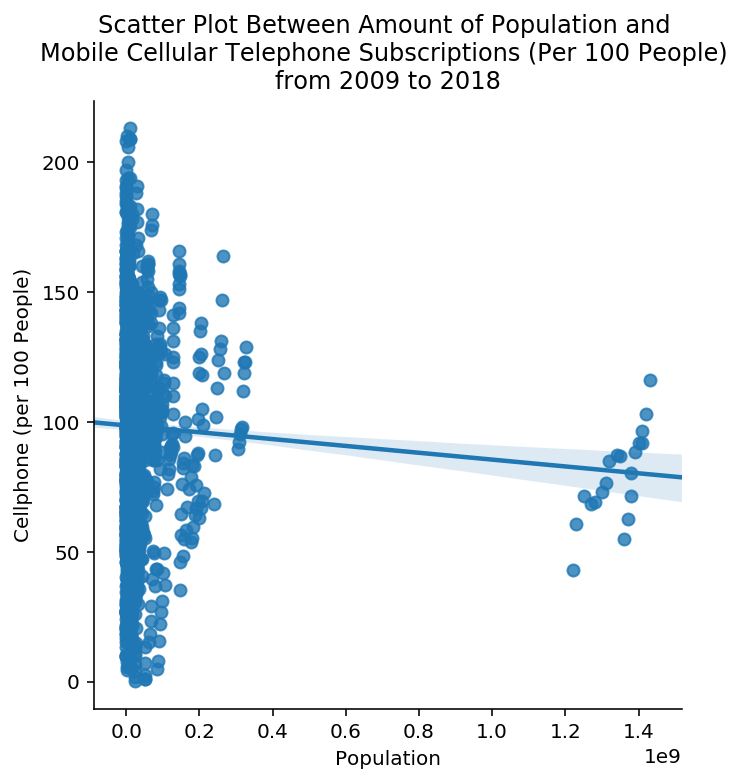

```python
sns.lmplot(x='population', y='cellphone_per_100_people', data=df_filter_10year_dropna[['cellphone_per_100_people', 'population']]);
plt.xlabel("Population")
plt.ylabel("Cellphone (per 100 People)")
plt.title("Scatter Plot Between Amount of Population and \nMobile Cellular Telephone Subscriptions (Per 100 People) \nfrom 2009 to 2018");
```

> - Scatter plots: The plot and the regression line show that the relationship between population and cellphone per 100 people is low frequency negative
> - Correlation: The corr() function gives a extremely low negative value between these two variables.

> The analysis shows that this relationship will have a high of cellphone per 100 people at the extremely low population.

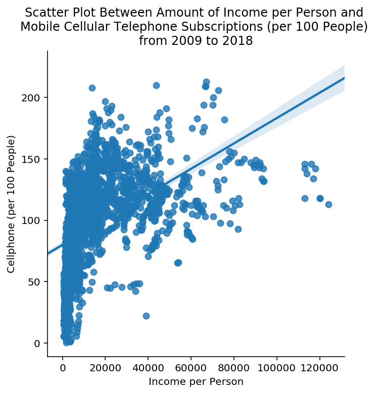

```python
sns.lmplot(x='income_per_person', y='cellphone_per_100_people', data=df_filter_10year_dropna[['cellphone_per_100_people', 'income_per_person']]);
plt.xlabel("Income per Person")
plt.ylabel("Cellphone (per 100 People)")
plt.title("Scatter Plot Between Amount of Income per Person and \nMobile Cellular Telephone Subscriptions (per 100 People) \nfrom 2009 to 2018");
```

> - Scatter plots: The plot and the regression line show that the relationship between income per person and cellphone per 100 people is positive
> - Correlation: The corr() function gives a positive value between these two variables.

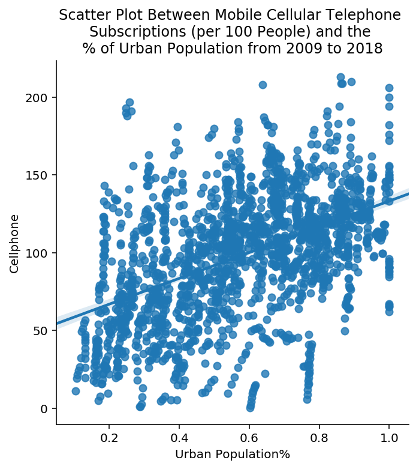

```python
sns.lmplot(x='urban_population%', y='cellphone_per_100_people', data=df_filter_10year_dropna[['cellphone_per_100_people', 'urban_population%']]);
plt.xlabel("Urban Population%")
plt.ylabel("Cellphone")
plt.title("Scatter Plot Between Mobile Cellular Telephone \nSubscriptions (per 100 People) and the \n% of Urban Population from 2009 to 2018");
```

We can see an overview of scatter plot and distribution of all variables as shown in the table below.

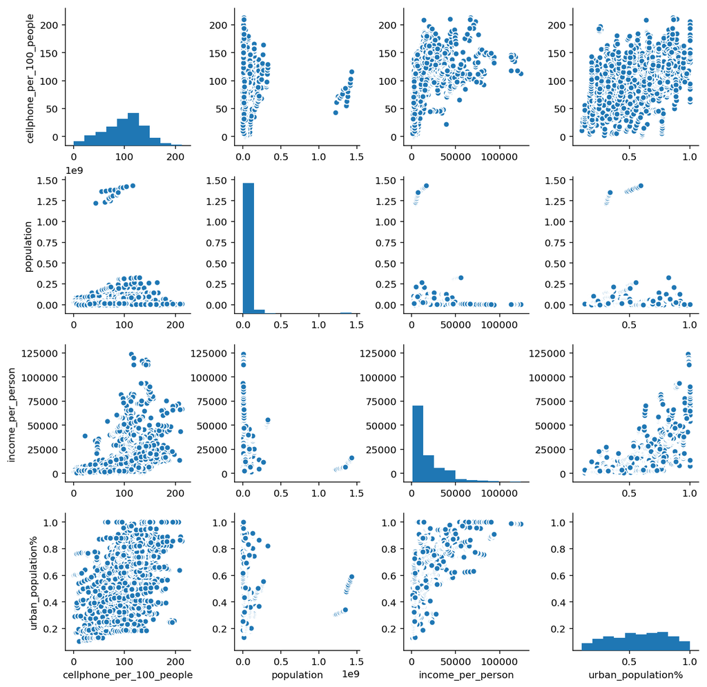

```python
sns.pairplot(df_filter_10year_dropna[['cellphone_per_100_people', 'population','income_per_person','urban_population%']]);
```

From the table above We can see an overview of trends in various variables at all. Which will be able to answer the question 5, but I will redo the plot for beauty and clarity.

### Question 5 - What is the trend between other variables in 2009 to 2018 (urban_population%, income_per_person and population)?

```python
df_filter_10year_dropna[['population','income_per_person','urban_population%']].corr()
```

|  | population | income_per_person | urban_population% |
| --- | --- | --- | --- |
| population | 1.000000 | -0.047347 | -0.052531 |
| income_per_person | -0.047347 | 1.000000 | 0.658376 |
| urban_population% | -0.052531 | 0.658376 | 1.000000 |

> The correlation value of these variables

[figure not shown]

```python
sns.lmplot(x='urban_population%', y='population', data=df_filter_10year_dropna[['urban_population%', 'population']]);
plt.xlabel("Population")
plt.ylabel("Urban Population%")
plt.title("Scatter Plot Between Amount of Population and the \n% of Urban Population from 2009 to 2018");
```

> Therefore, This relationship is no correlation

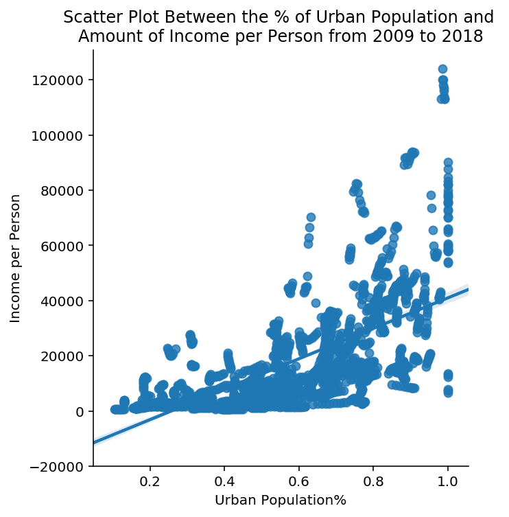

```python
sns.lmplot(x='urban_population%', y='income_per_person', data=df_filter_10year_dropna[['urban_population%', 'income_per_person']]);
plt.xlabel("Urban Population%")
plt.ylabel("Income per Person")
plt.title("Scatter Plot Between the % of Urban Population and \nAmount of Income per Person from 2009 to 2018");
```

> - Scatter plots: The plot and the regression line show that the relationship between income per person and urban_population% is positive
> - Correlation: The corr() function gives a positive value between these two variables.

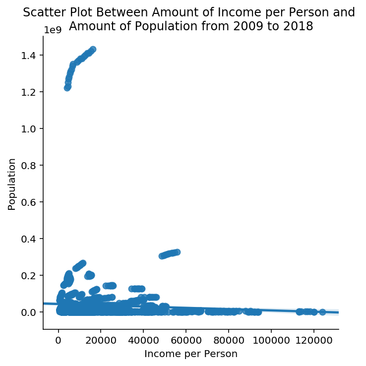

```python
sns.lmplot(x='income_per_person', y='population', data=df_filter_10year_dropna[['income_per_person', 'population']]);
plt.xlabel("Income per Person")
plt.ylabel("Population")
plt.title("Scatter Plot Between Amount of Income per Person and \nAmount of Population from 2009 to 2018");
```

> - Scatter plots: The plot and the regression line show that the relationship between population and income per person is a extremely low negative
> - Correlation: The corr() function gives a extremely low negative value between these two variables.

> Therefore, This relationship is no correlation

## Conclusions

From the dataset in 2009 to 2018